# Course 5 Project 1

SK Sharma

September 28, 2018

# Project 1

## Code for reading in the dataset and/or processing the data.

```r
if(!dir.exists("c5p1")){dir.create("c5p1")}
 setwd("./c5p1")
url<-"https://d396qusza40orc.cloudfront.net/repdata%2Fdata%2Factivity.zip"
 if(!file.exists("c5p1.zip")){download.file(url, destfile = "c5p1.zip")}
 if(!file.exists("activity.csv")){unzip("c5p1.zip")}
data<-read.csv("activity.csv", sep = ",", header = TRUE)
head(data)
```

```
##   steps       date interval
## 1    NA 2012-10-01        0
## 2    NA 2012-10-01        5
## 3    NA 2012-10-01       10
## 4    NA 2012-10-01       15
## 5    NA 2012-10-01       20
## 6    NA 2012-10-01       25
```

## Histogram of the total number of steps taken each day.

```r
dsteps<-tapply(data$steps, data$date, sum, na.rm=TRUE)
head(dsteps)
```

```
## 2012-10-01 2012-10-02 2012-10-03 2012-10-04 2012-10-05 2012-10-06
##          0        126      11352      12116      13294      15420
```

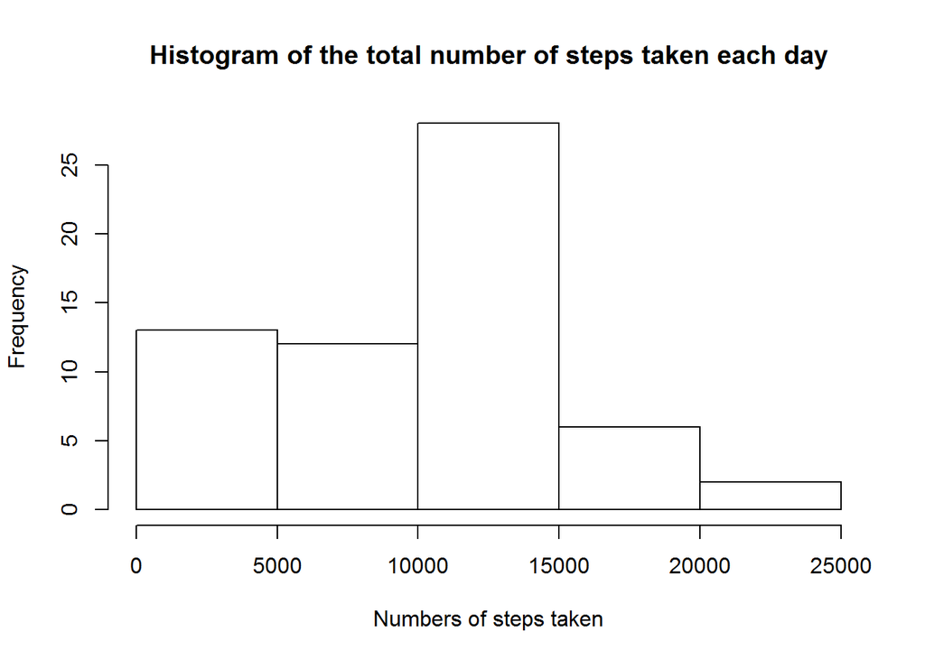

```r
hist(dsteps, main = "Histogram of the total number of steps taken each day", xlab = "Numbers of steps taken")
```

## Mean and median number of steps taken each day.

```r
dsteps<-data.frame(dsteps)
colnames(dsteps)[1]<-"Dates"
mean(dsteps$Dates)
```

```
## [1] 9354.23
```

```r
median(dsteps$Dates)
```

```
## [1] 10395
```

## Time series plot of the average number of steps taken.

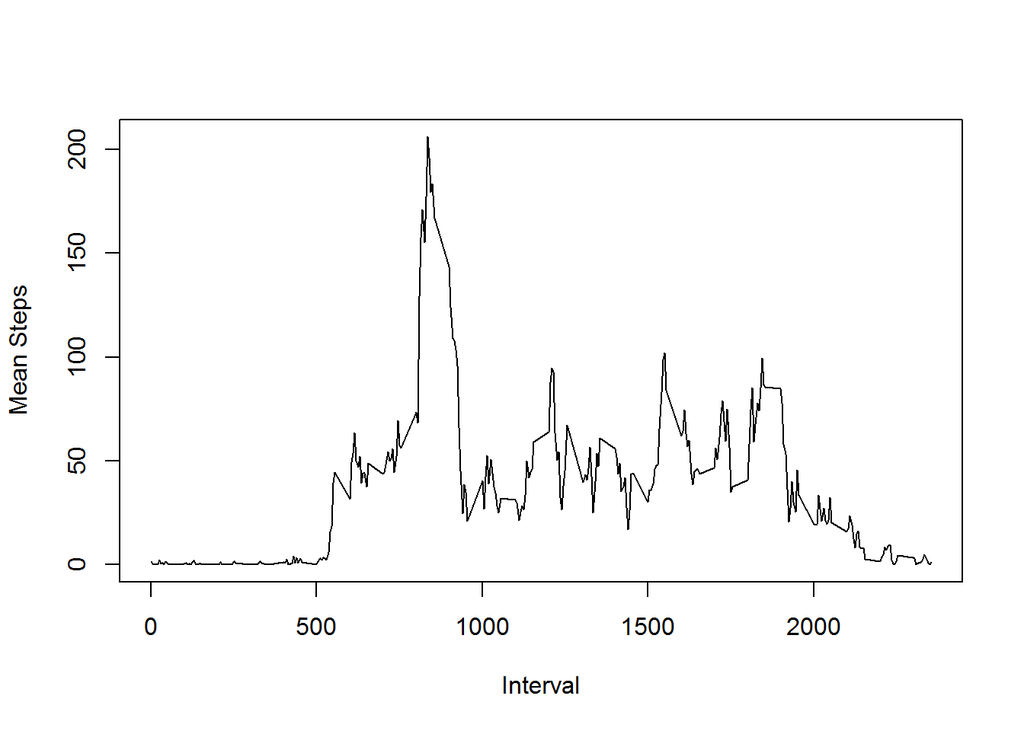

```r
dinterval<-tapply(data$steps, data$interval, mean, na.rm=TRUE)
dinterval<-data.frame(dinterval)
dataint<-data.frame(interval=row.names(dinterval), steps=dinterval, row.names = NULL)
plot(as.numeric(as.character(dataint$interval)), dataint$dinterval, type="l", xlab="Interval", ylab="Mean Steps")
```

## The 5-minute interval that, on average, contains the maximum number of steps

```r
dataint[which.max(dataint$dinterval),]
```

```
##     interval dinterval
## 104      835  206.1698
```

## 6. The total number of missing values in the dataset (i.e. the total number of rows with NAs)

```r
sum(!complete.cases(data$steps))
```

```
## [1] 2304
```

## Code to describe and show a strategy for imputing missing data

```r
dataf<-data
for(i in 1 : length(dataf$steps)){
        if(is.na(dataf[i,1])){
        r<-which(dataint$interval==dataf[i,3])
        dataf[i,1]<-dataint[r,2]}
        }
head(dataf)
```

```
##       steps       date interval
## 1 1.7169811 2012-10-01        0
## 2 0.3396226 2012-10-01        5
## 3 0.1320755 2012-10-01       10
## 4 0.1509434 2012-10-01       15
## 5 0.0754717 2012-10-01       20
## 6 2.0943396 2012-10-01       25
```

## Histogram of the total number of steps taken each day and the mean and median total number of steps taken per day.

```r
dfsteps<-data.frame(steps=tapply(dataf$steps, dataf$date, sum),date=levels(factor(dataf$date)),row.names = NULL)
head(dfsteps)
```

```
##      steps       date
## 1 10766.19 2012-10-01
## 2   126.00 2012-10-02
## 3 11352.00 2012-10-03
## 4 12116.00 2012-10-04
## 5 13294.00 2012-10-05
## 6 15420.00 2012-10-06
```

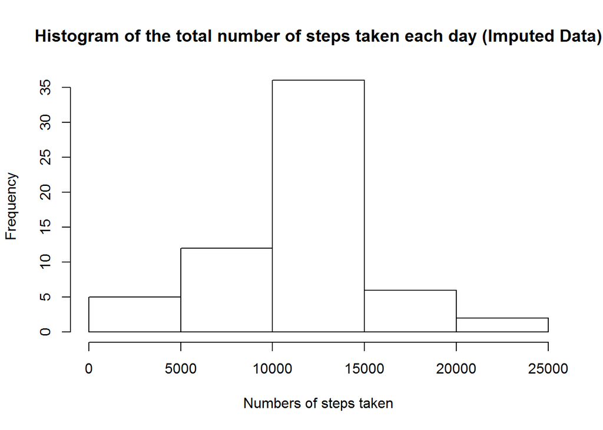

```r
hist(dfsteps$steps, main = "Histogram of the total number of steps taken each day (Imputed Data)", xlab = "Numbers of steps taken")
```

```r
mean(dfsteps$steps)
```

```
## [1] 10766.19
```

```r
median(dfsteps$steps)
```

```
## [1] 10766.19
```

- Do these values differ from the estimates from the first part of the assignment?

Data slightly differ one can observe this by comparing the means and meadians which increases in the imputed data.

## Creating a new factor variable in the dataset with two levels - “weekday” and “weekend” indicating whether a given date is a weekday or weekend day.

```r
dataw<-data.frame(cbind(dataf,Days=weekdays(as.Date(dataf$date))))
dataw$Days<-ifelse(dataw$Days=="Saturday"|dataw$Days=="Sunday", "weekend","weekday")
head(dataw)
```

```
##       steps       date interval    Days
## 1 1.7169811 2012-10-01        0 weekday
## 2 0.3396226 2012-10-01        5 weekday
## 3 0.1320755 2012-10-01       10 weekday
## 4 0.1509434 2012-10-01       15 weekday
## 5 0.0754717 2012-10-01       20 weekday
## 6 2.0943396 2012-10-01       25 weekday
```

```r
levels(as.factor(dataw$Days))
```

```
## [1] "weekday" "weekend"
```

## Making a panel plot containing a time series plot of the 5-minute interval (x-axis) and the average number of steps taken, averaged across all weekday days or weekend days (y-axis).

```r
library(dplyr)
```

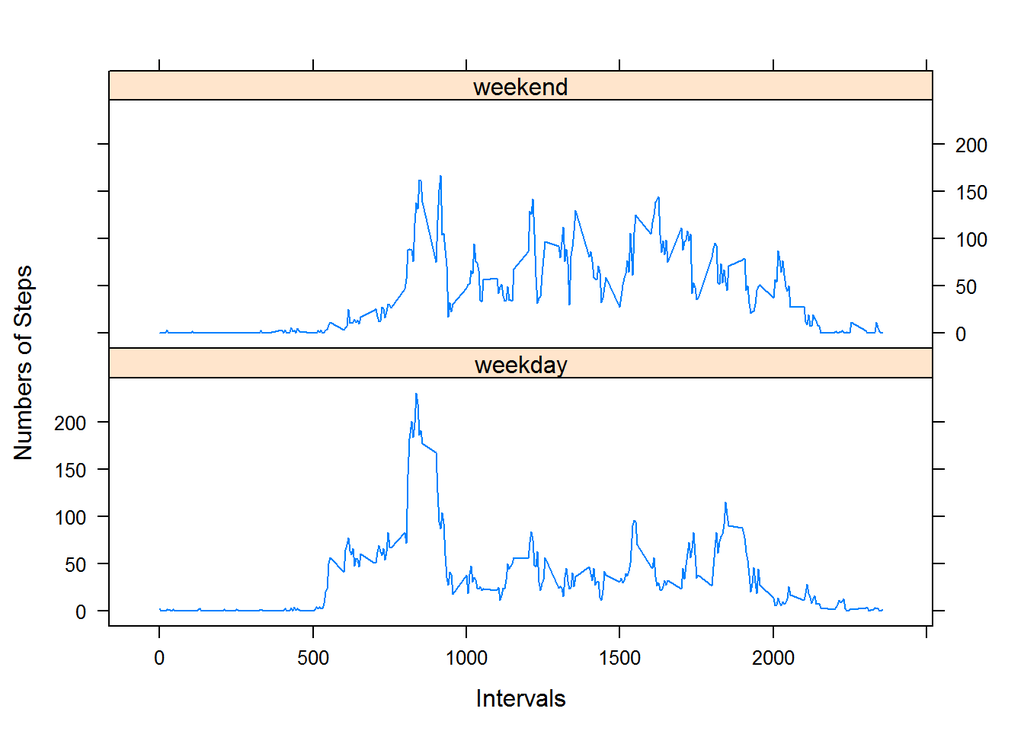

```r
datap<-transform(dataw, Days=factor(Days))
datafp<-aggregate(steps ~ interval + Days, datap, mean)
library(lattice)
xyplot(datafp$steps~datafp$interval|datafp$Days, layout=c(1,2), type="l", xlab = "Intervals", ylab = "Numbers of Steps")
```